# 인공지능의 이해와 활용과목 Iris 데이터 분류과제

2017195151 윤정하

2019-04-22

### 1. Prepare Data

#### Iris Data

This is perhaps the best known database to be found in the pattern recognition literature. Fisher’s paper is a classic in the field and is referenced frequently to this day. (See Duda & Hart, for example.) The data set contains “3 classes of 50 instances each”, where each class refers to a type of iris plant. One class is linearly separable from the other 2; the latter are NOT linearly separable from each other.

Predicted attribute: class of iris plant.

This is an exceedingly simple domain.

This data differs from the data presented in Fishers article (identified by Steve Chadwick, spchadwick ‘@’ espeedaz.net ). The 35th sample should be: 4.9,3.1,1.5,0.2,“Iris-setosa” where the error is in the fourth feature. The 38th sample: 4.9,3.6,1.4,0.1,“Iris-setosa” where the errors are in the second and third features.

Attribute Information:

- sepal(꽃잎) length in cm
- sepal(꽃잎) width in cm
- petal(꽃받침) length in cm
- petal(꽃받침) width in cm
- class: (Iris 꽃종류 3가지)
- Iris Setosa
- Iris Versicolour
- Iris Virginica

```python
import numpy as np
import matplotlib.pyplot as plt
import pandas as pd
import os
os.environ['QT_QPA_PLATFORM_PLUGIN_PATH']='C:/Users/JunghaYun/Anaconda3/Library/plugins/platforms'
from sklearn import datasets
```

```python
iris = datasets.load_iris()

# sepal length in cm, sepal width in cm
X = iris.data
T = iris.target

pool = np.arange(X.shape[0])
np.random.shuffle(pool)

train_indices = pool[:120]
test_indices = pool[120:]

train_x = X[train_indices]
train_t = T[train_indices]

test_x = X[test_indices]
test_t = T[test_indices]
```

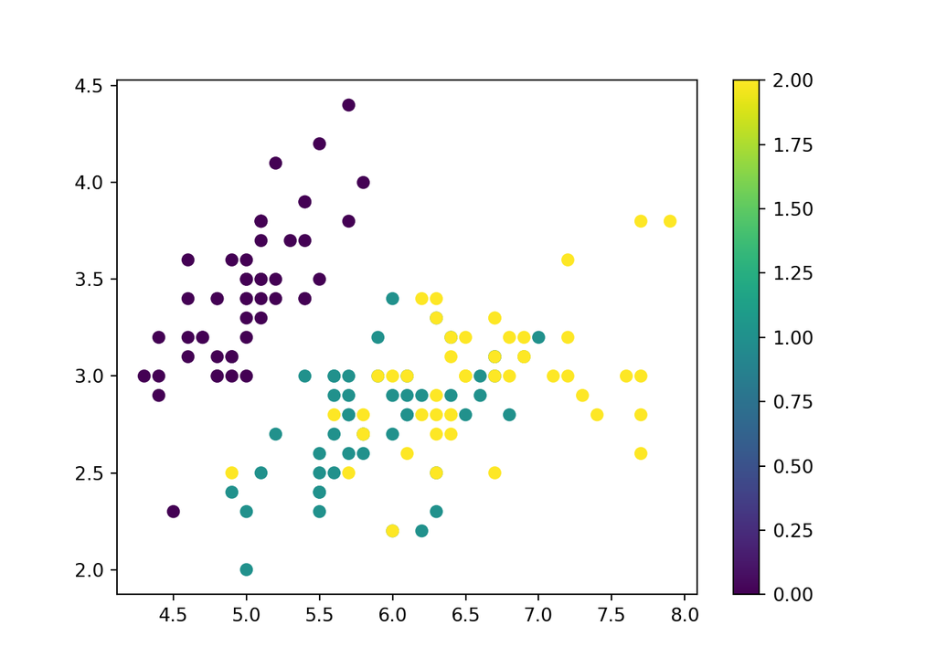

```python
plt.scatter(X[:, 0], X[:, 1], c = T)
plt.colorbar()
plt.show() #3가지로 꽃이 분류됨
```

### 2. Define Model

```python
def sigmoid(x):
    return 1 / (1 + np.exp(-x))
```

```python
def softmax(x):
    if x.ndim == 2:
        x = x.T
        x = x - np.max(x, axis=0)
        y = np.exp(x) / np.sum(np.exp(x), axis=0)
        return y.T

    x = x - np.max(x)
    return np.exp(x) / np.sum(np.exp(x))
```

```python
def cross_entropy_error(y, t):
    if y.ndim == 1:
        t = t.reshape(1, t.size)
        y = y.reshape(1, y.size)

    if t.size == y.size:
        t = t.argmax(axis=1)

    batch_size = y.shape[0]

    return - np.sum( np.log( y[np.arange(batch_size), t] + 1e-7) ) / batch_size
```

```python
def numerical_gradient(f, x):
    h = 0.01
    grad = np.zeros_like(x)

    it = np.nditer(x, flags=['multi_index'])
    while not it.finished:
        idx = it.multi_index
        tmp_val = x[idx]
        x[idx] = float(tmp_val) + h
        fxh1 = f(x) # f(x+h)           #f(x)가 나오기에 lambda ftn 씀

        x[idx] = tmp_val - h
        fxh2 = f(x) # f(x-h)
        grad[idx] = (fxh1 - fxh2) / (2*h)

        x[idx] = tmp_val
        it.iternext()

    return grad
```

#### 2 layer net

```python
class TwoLayerNet:

    def __init__(self, input_size, hidden_size, output_size, weight_init_std=0.01):
        self.params = {}
        self.params['W1'] = weight_init_std * np.random.randn(input_size, hidden_size)
        self.params['b1'] = np.zeros(hidden_size)
        self.params['W2'] = weight_init_std * np.random.randn(hidden_size, output_size)
        self.params['b2'] = np.zeros(output_size)

    def predict(self, x):
        W1 = self.params['W1']
        b1 = self.params['b1']
        W2 = self.params['W2']
        b2 = self.params['b2']

        a1=np.dot(x,W1)+b1
        z1=sigmoid(a1)
        a2=np.dot(z1,W2)+b2
        y=softmax(a2)

        return y

    def loss(self, x, t):

        y = self.predict(x)

        return cross_entropy_error(y, t)

    def n_gradient(self, x, t):
        loss_W = lambda W: self.loss(x, t)

        grads = {}
        grads['W1'] = numerical_gradient(loss_W, self.params['W1'])
        grads['b1'] = numerical_gradient(loss_W, self.params['b1'])
        grads['W2'] = numerical_gradient(loss_W, self.params['W2'])
        grads['b2'] = numerical_gradient(loss_W, self.params['b2'])

        return grads
```

#### 3 layer net

```python
class ThreeLayerNet:

    def __init__(self, input_size, hidden1_size, hidden2_size, output_size, weight_init_std=0.01):
        self.params = {}
        self.params['W1'] = weight_init_std * np.random.randn(input_size, hidden1_size)
        self.params['b1'] = np.zeros(hidden1_size)
        self.params['W2'] = weight_init_std * np.random.randn(hidden1_size, hidden2_size)
        self.params['b2'] = np.zeros(hidden2_size)
        self.params['W3'] = weight_init_std * np.random.randn(hidden2_size, output_size)
        self.params['b3'] = np.zeros(output_size)

    def predict(self, x):
        W1 = self.params['W1']
        b1 = self.params['b1']
        W2 = self.params['W2']
        b2 = self.params['b2']
        W3 = self.params['W3']
        b3 = self.params['b3']

        a1=np.dot(x,W1)+b1
        z1=sigmoid(a1)
        a2=np.dot(z1,W2)+b2
        z2=sigmoid(a2)
        a3=np.dot(z2,W3)+b3
        y=softmax(a3)

        return y

    def loss(self, x, t):

        y = self.predict(x)

        return cross_entropy_error(y, t)

    def n_gradient(self, x, t):
        loss_W = lambda W: self.loss(x, t)

        grads = {}
        grads['W1'] = numerical_gradient(loss_W, self.params['W1']) # MODIFY THIS
        grads['b1'] = numerical_gradient(loss_W, self.params['b1']) # MODIFY THIS
        grads['W2'] = numerical_gradient(loss_W, self.params['W2']) # MODIFY THIS
        grads['b2'] = numerical_gradient(loss_W, self.params['b2']) # MODIFY THIS
        grads['W3'] = numerical_gradient(loss_W, self.params['W3']) # MODIFY THIS
        grads['b3'] = numerical_gradient(loss_W, self.params['b3']) # MODIFY THIS


        return grads
```

### 3. Train Model

#### 2 layer net

```python
learning_rate = 0.1  # 여기서는 크게 하는게 유리: 0.001->0.01->0.1 , 손실이 0에 가까울수록 좋음

net = TwoLayerNet(train_x.shape[1], 10, 3)

train_loss_list = []

for i in range(1000):

    grad = net.n_gradient(train_x,train_t)

    for key in ('W1', 'b1', 'W2', 'b2'):
        net.params[key]-=learning_rate*grad[key]

    loss = net.loss(train_x,train_t)
    train_loss_list.append(loss)

    if i % 50 == 0:
        print('iter: {} loss: {}'.format(i, loss))
```

```
## iter: 0 loss: 1.0987349497674221
## iter: 50 loss: 1.0959745737132076
## iter: 100 loss: 1.0781710534399878
## iter: 150 loss: 0.9779020956484153
## iter: 200 loss: 0.7437760051880252
## iter: 250 loss: 0.5766136598802493
## iter: 300 loss: 0.4988984202153946
## iter: 350 loss: 0.45301339509887106
## iter: 400 loss: 0.4163951792049448
## iter: 450 loss: 0.3826343769136024
## iter: 500 loss: 0.3508336849967567
## iter: 550 loss: 0.3214158027276478
## iter: 600 loss: 0.2947840255338573
## iter: 650 loss: 0.27106462826810707
## iter: 700 loss: 0.2501572441006289
## iter: 750 loss: 0.23183435797769372
## iter: 800 loss: 0.21581618315773224
## iter: 850 loss: 0.2018149184365138
## iter: 900 loss: 0.18955846229169707
## iter: 950 loss: 0.17880166260439656
```

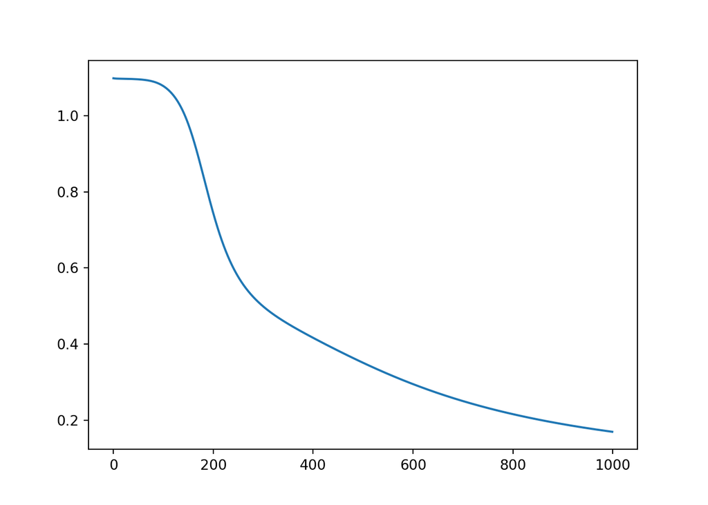

```python
plt.plot(train_loss_list)
plt.show()
```

#### 3 layer net

```python
learning_rate = 1.1  # MODIFY THIS: 크게 하는게 유리: 0.001->0.01->0.1

net = ThreeLayerNet(train_x.shape[1], 10, 10, 3) #node 개수 마음대로 추가

train_loss_list = []

for i in range(1000):

    grad = net.n_gradient(train_x,train_t)

    for key in ('W1', 'b1', 'W2', 'b2', 'W3', 'b3'):
        net.params[key]-=learning_rate*grad[key]

    loss = net.loss(train_x,train_t)
    train_loss_list.append(loss)

    if i % 50 == 0:
        print('iter: {} loss: {}'.format(i, loss))
```

```
## iter: 0 loss: 1.0978342385930864
## iter: 50 loss: 1.0977772631825267
## iter: 100 loss: 1.0977763037051842
## iter: 150 loss: 1.0977748560289282
## iter: 200 loss: 1.097772418774628
## iter: 250 loss: 1.097767852412217
## iter: 300 loss: 1.0977580799550344
## iter: 350 loss: 1.097732700806234
## iter: 400 loss: 1.0976421964574958
## iter: 450 loss: 1.0970512102258783
## iter: 500 loss: 1.0776584065785957
## iter: 550 loss: 0.39795380559516264
## iter: 600 loss: 0.37802164036128094
## iter: 650 loss: 0.45341468233857013
## iter: 700 loss: 0.8290440650099374
## iter: 750 loss: 0.2900186995304684
## iter: 800 loss: 0.18341066315134047
## iter: 850 loss: 0.1573016037242461
## iter: 900 loss: 0.2559268313145678
## iter: 950 loss: 0.246202974510654
```

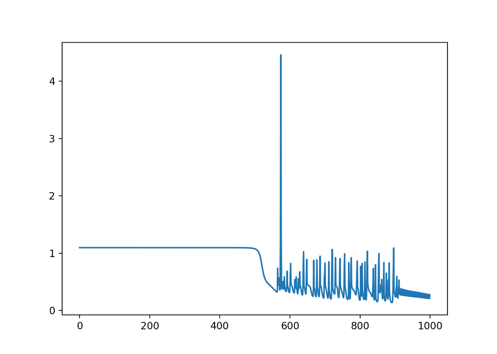

```python
plt.plot(train_loss_list)
plt.show()
```

### 4. Test Model

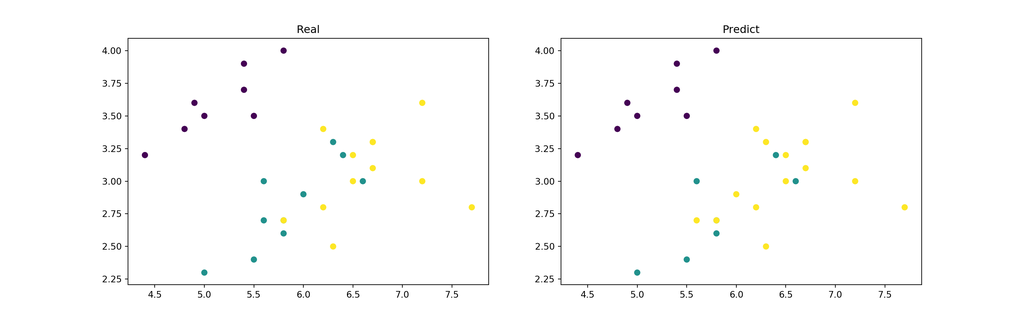

```python
test_y = net.predict(test_x)
test_y = np.argmax(test_y, axis=1)

fig = plt.figure(figsize=(16, 5))

ax1 = fig.add_subplot(1, 2, 1)
ax2 = fig.add_subplot(1, 2, 2)

ax1.scatter(test_x[:, 0], test_x[:, 1], c = test_t)
ax2.scatter(test_x[:, 0], test_x[:, 1], c = test_y)

ax1.set_title('Real')
ax2.set_title('Predict')

plt.show()
```

#### 3 layer의 경우

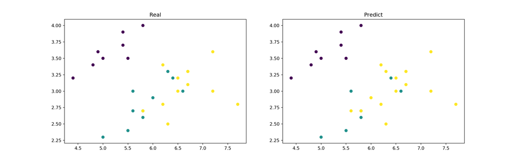

```python
test_y = net.predict(test_x)
test_y = np.argmax(test_y, axis=1)

fig = plt.figure(figsize=(16, 5))

ax1 = fig.add_subplot(1, 2, 1)
ax2 = fig.add_subplot(1, 2, 2)

ax1.scatter(test_x[:, 0], test_x[:, 1], c = test_t)
ax2.scatter(test_x[:, 0], test_x[:, 1], c = test_y)

ax1.set_title('Real')
ax2.set_title('Predict')

plt.show()
```